# Project1

—-

01 11 2019

# Создание единой таблицы с данными

```r
dt<-data.frame()
files_opener <- function(p){
  library(data.table)
  all.files <- list.files(path=p,pattern = ".csv",full.names = T)
  l <- lapply(all.files, fread, sep=",")
  dt <<- rbindlist(l)
}
files_opener("C:/Users/Alexandra Dolgikh/Downloads/Data/")
dt<-as.data.frame(dt)
colnames(dt)[2]<-'Sex'
```

### После создания таблицы нам нужно проверить ее на:

- целостность
- корректность данных

Сначала проверим, что число наблюдений равно **4177**:

```r
nrow(dt)
```

```
## [1] 4177
```

Видим, что таблица действительно содержит 4177 значений.

Далее необходимо проверить данные на **корректность**.

Поскольку в данной работе проводилось измерение количественных параметров, логично предположить, что все столбцы кроме переменной Sex должны быть типа *numeri*c. Для проверки этого воспользуемся функцией str

```r
str(dt)
```

```
## 'data.frame':    4177 obs. of  9 variables:
##  $ Rings         : chr  "18" "14" "8" "12" ...
##  $ Sex           : chr  "2" "3" "1" "1" ...
##  $ Length        : chr  "0.575" "0.385" "0.475" "0.665" ...
##  $ Diameter      : num  0.45 0.305 0.37 0.525 0.12 0.16 0.565 0.43 0.175 0.3 ...
##  $ Height        : num  0.17 0.095 0.125 0.18 0.075 0.05 0.2 0.15 0.055 0.115 ...
##  $ Whole_weight  : num  1.048 0.252 0.649 1.429 0.117 ...
##  $ Shucked_weight: num  0.3775 0.0915 0.347 0.6715 0.0455 ...
##  $ Viscera_weight: num  0.171 0.055 0.136 0.29 0.029 ...
##  $ Shell_weight  : num  0.385 0.09 0.142 0.4 0.0345 0.015 0.494 0.221 0.018 0.0935 ...
```

Видим, что первые три столбца представляют тип character. Для начала проверим, все ли значения этих столбцов записаны в числовом виде. Начнем со столбца **Sex**

```r
unique(sort(dt$Sex))
```

```
## [1] "1"     "2"     "3"     "male"  "one"   "three"
```

```r
dt$Sex <- gsub(dt$Sex, pattern = "male", replacement = 1)
dt$Sex <- gsub(dt$Sex, pattern = "one", replacement = 1)
dt$Sex <- gsub(dt$Sex, pattern = "three", replacement = 1)
unique(sort(dt$Sex))
```

```
## [1] "1" "2" "3"
```

Аналогичную операцию проведем со столбцом **Rings**

```r
unique(sort(dt$Rings))
```

```
##  [1] "1"    "10"   "11"   "12"   "13"   "14"   "15"   "16"   "17"   "18"
## [11] "19"   "2"    "20"   "21"   "22"   "23"   "24"   "25"   "26"   "27"
## [21] "29"   "3"    "4"    "5"    "6"    "7"    "8"    "9"    "nine"
```

Опять видим, что есть значение записанное не цифрами, изменим это и сразу проверим.

```r
dt$Rings <- gsub(dt$Rings, pattern = "nine", replacement = 9)
unique(sort(dt$Rings))
```

```
##  [1] "1"  "10" "11" "12" "13" "14" "15" "16" "17" "18" "19" "2"  "20" "21"
## [15] "22" "23" "24" "25" "26" "27" "29" "3"  "4"  "5"  "6"  "7"  "8"  "9"
```

Теперь поработаем со столбцом **Length**. Если посмотреть начало таблицы видим, что в этом столбце находятся числовые значения, тем не менее тип вектора - character. Сначала, не изменяя столбец попробуем перевести этот вектор в numeric, присвоив это значение другой переменной. При превращении вектора в numeric значения, которые не могут быть переведены в числовой вид, будут преобразованы в NA, а значит, выбрав только те строчки исходной таблицы, где в векторе x содержатся *NA*, может посмотреть, какие же именно это значения.

```r
x<-as.numeric(dt$Length)
dt[is.na(x),]
```

```
##      Rings Sex                           Length Diameter Height
## 136      8   1                             <NA>    0.385  0.110
## 1224     6   3                             <NA>    0.325  0.100
## 1738    11   2                             <NA>    0.440  0.175
## 1908    10   2                             <NA>    0.435  0.175
## 2886     9   1                             <NA>    0.255  0.090
## 3059    10   2                             <NA>    0.400  0.125
## 3103     8   3 No data! I forgot to mesure it!(    0.310  0.095
##      Whole_weight Shucked_weight Viscera_weight Shell_weight
## 136        0.5785         0.2530         0.1600       0.1400
## 1224       0.3940         0.2080         0.0655       0.1060
## 1738       0.7745         0.2985         0.1875       0.2650
## 1908       0.9820         0.4055         0.2495       0.2700
## 2886       0.2005         0.0940         0.0295       0.0630
## 3059       0.6675         0.2610         0.1315       0.2200
## 3103       0.3425         0.1785         0.0640       0.0855
```

```r
dt$Length <- as.numeric(dt$Length)
```

Проверим результат

```r
str(dt)
```

```
## 'data.frame':    4177 obs. of  9 variables:
##  $ Rings         : chr  "18" "14" "8" "12" ...
##  $ Sex           : chr  "2" "3" "1" "1" ...
##  $ Length        : num  0.575 0.385 0.475 0.665 0.28 0.22 0.72 0.55 0.235 0.4 ...
##  $ Diameter      : num  0.45 0.305 0.37 0.525 0.12 0.16 0.565 0.43 0.175 0.3 ...
##  $ Height        : num  0.17 0.095 0.125 0.18 0.075 0.05 0.2 0.15 0.055 0.115 ...
##  $ Whole_weight  : num  1.048 0.252 0.649 1.429 0.117 ...
##  $ Shucked_weight: num  0.3775 0.0915 0.347 0.6715 0.0455 ...
##  $ Viscera_weight: num  0.171 0.055 0.136 0.29 0.029 ...
##  $ Shell_weight  : num  0.385 0.09 0.142 0.4 0.0345 0.015 0.494 0.221 0.018 0.0935 ...
```

Что же делать с NA? Есть вариант убрать строчки,содержащие NA, но он уберет довольно много данных.

```r
dt_wo_na <- dt[complete.cases(dt),]
```

Второй вариант это заменить NA на среднее. Чтобы исключить замену NA на среднее в факторной переменной Sex сделаем соответсвующий фильтр:

```r
library(dplyr)
```

```r
dt <- dt %>% mutate_if(is.numeric, funs(ifelse(is.na(.), mean(.,na.rm=T), .)))
```

Теперь можно приступить к рассчетам!

# Рассчеты

### Для начала нам нужно узнать, каково среднее значение длины раковины у различных полов, а также у ювенильной стадии, а затем и стандартное отклонение для тех же групп.

```r
m<-dt %>% filter(Sex!='NA') %>% group_by(Sex) %>% summarise(mean(Length))
s<-dt %>% filter(Sex!='NA') %>% group_by(Sex) %>% summarise(sd(Length))
print(m)
```

```
## # A tibble: 3 x 2
##   Sex   `mean(Length)`
##   <chr>          <dbl>
## 1 1              0.561
## 2 2              0.579
## 3 3              0.428
```

```r
print(s)
```

```
## # A tibble: 3 x 2
##   Sex   `sd(Length)`
##   <chr>        <dbl>
## 1 1           0.103
## 2 2           0.0862
## 3 3           0.109
```

### Теперь узнаем у какого процента моллюсков значение переменной Height не превышает 0.165

```r
height165 <- dt%>% filter(Height <= 0.165)
Height_percent <- nrow(height165)/nrow(dt)*100
print(round(Height_percent,2))
```

```
## [1] 75.89
```

### Теперь узнаем значение переменной Length выше чем у 92%

Для начала вычислим, сколько наблюдений составляют 92%

```r
0.92*4177
```

```
## [1] 3842.84
```

Теперь, найдем 3843 наблюдение в отсортированном векторе *Length*

```r
Length_sort <- sort(dt$Length)
Length_sort[3843]
```

```
## [1] 0.67
```

Наконец проведем Z-стандартизацию переменной Length и сохраним получившийся вектор как Length_z_scores

```r
Length_z_scores <- (dt$Length - mean(dt$Length,na.rm=T))/sd(dt$Length)
```

# Сравнения и выявление корреляций

## сравнение диаметра моллюсков с 5 и 15 кольцами

Для сравнения диаметра раковины у улиток с 5 и 15 кольцами для начала нужно сохранить значения диаметра, относящиеся к этим двум группам в отдельные вектора

```r
library(ggplot2)
Diameter_5 <- dt %>% filter(Rings==5) %>% select(Diameter)
Diameter_15 <- dt %>% filter(Rings==15) %>% select(Diameter)
```

Теперь нужно определеиться с тем, параметрический или непараметрический тест будем использовать дял анализа. Для начала проверим сколько вообще значений включают данные группы.

```r
a<- length(Diameter_5$Diameter)
b<- length(Diameter_15$Diameter)
```

Получаем значения 115 и 103, то есть объем не очень большой, поэтому перед применением параметрического теста проверим данные на нормальность.

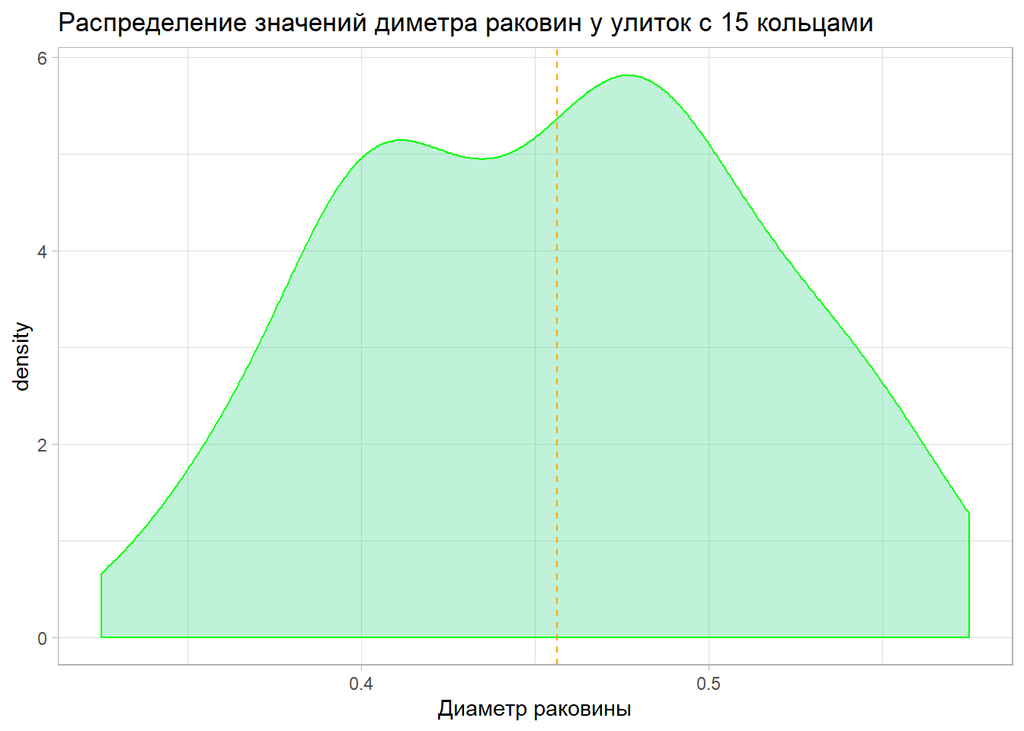

```r
ggplot(Diameter_15,aes(x=Diameter_15[,1]))+geom_density(colour='green',fill='springgreen3',alpha=0.25)+xlab('Диаметр раковины')+ggtitle('Распределение значений диметра раковин у улиток с 15 кольцами')+theme_light()+geom_vline(aes(xintercept=mean(Diameter_15[,1])),linetype="dashed",colour='orange')
```

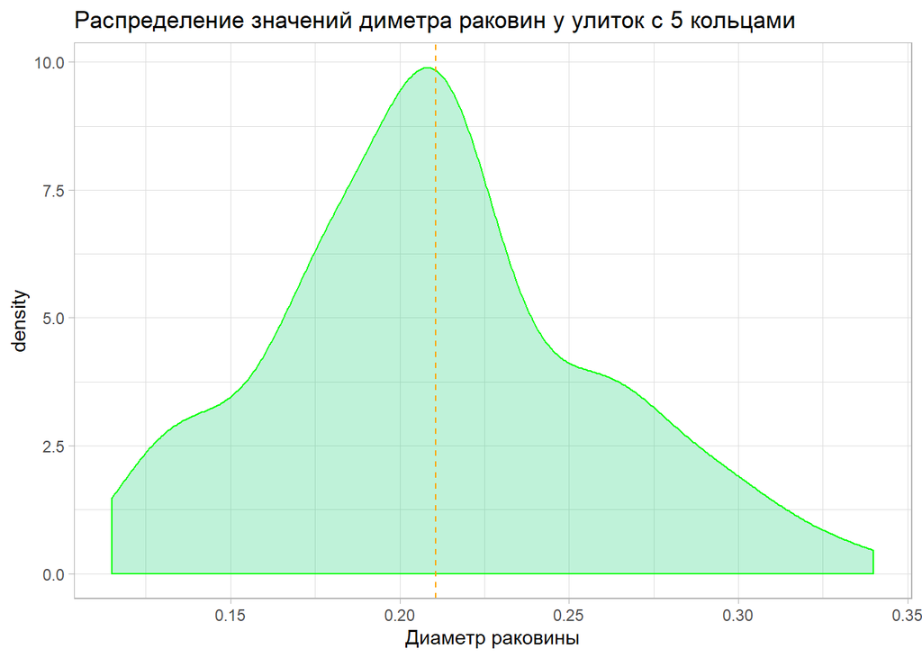

```r
ggplot(Diameter_5,aes(x=Diameter_5[,1]))+geom_density(colour='green',fill='springgreen3',alpha=0.25)+xlab('Диаметр раковины')+ggtitle('Распределение значений диметра раковин у улиток с 5 кольцами')+theme_light()+geom_vline(aes(xintercept=mean(Diameter_5[,1])),linetype="dashed",colour='orange')
```

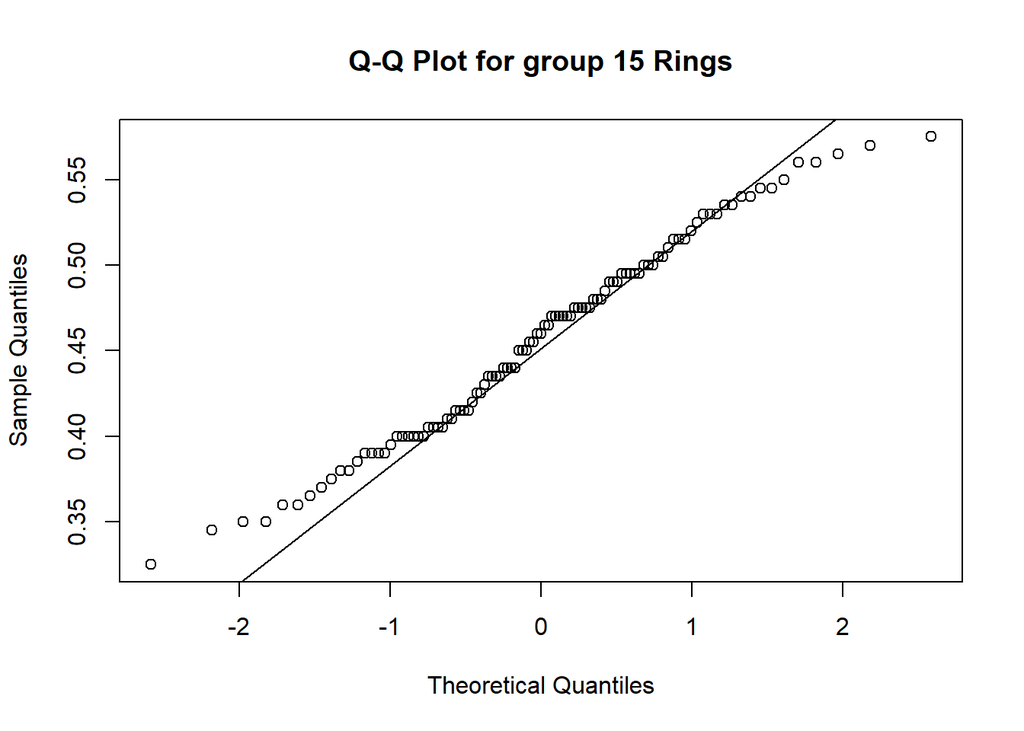

```r
qqnorm(y=Diameter_15[,1],main="Q-Q Plot for group 15 Rings",xlab = "Theoretical Quantiles", ylab = "Sample Quantiles")
qqline(Diameter_15[,1])
```

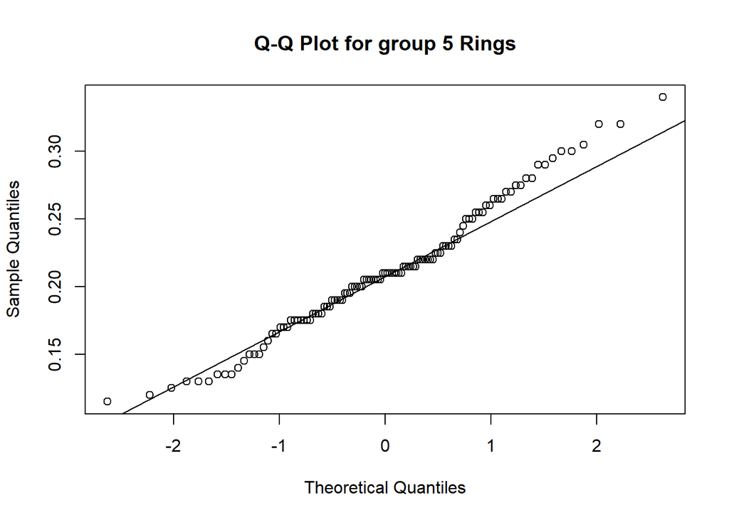

```r
qqnorm(Diameter_5[,1],main="Q-Q Plot for group 5 Rings",xlab = "Theoretical Quantiles", ylab = "Sample Quantiles")
qqline(Diameter_5[,1])
```

Видим,что распределение значений близко к нормальному,поэтому для сравнения можем применить t-test.

```r
f <- t.test(Diameter_15,Diameter_5)
```

Видим, что t-значение больше табличного 33.6363232 и значение p-value 3.379468410^{-83}, значит отвергаем нулевую гипотезу о равенстве средних и принимаем альтернативную, а значит между значениями диаметра у улиток с 15 и 5 кольцами есть разница.

### Про корреляцию между Diameter и Whole_weight

Для того, чтобы проверить, есть ли зависимость между переменными, сделаем корреляционный анализ. Для начала проверим распределение на нормальность построив density_plot и Q-Q-Plot

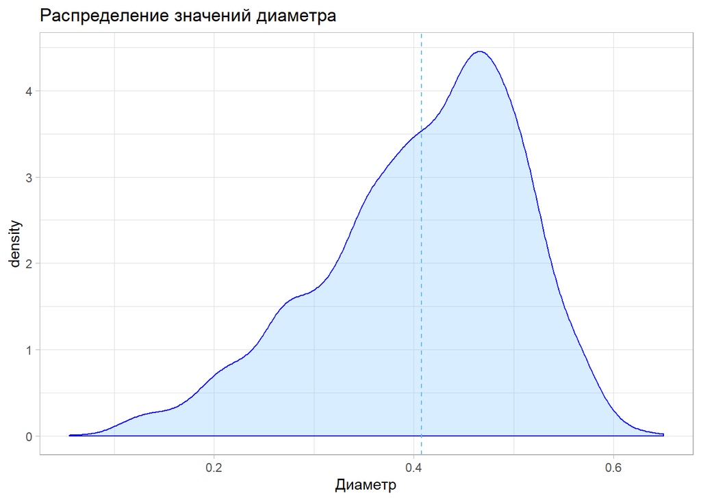

```r
ggplot(dt,aes(x=Diameter))+geom_density(colour='blue',fill='steelblue1',alpha=0.25)+xlab('Диаметр')+ggtitle('Распределение значений диаметра')+theme_light()+geom_vline(aes(xintercept=mean(Diameter)),linetype="dashed",colour='steelblue1')
```

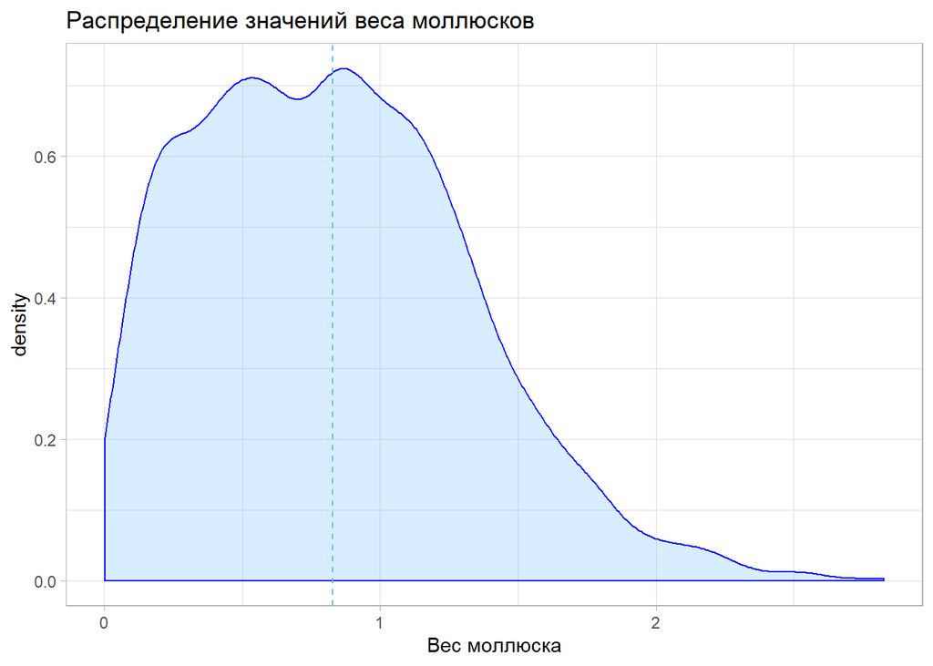

```r
ggplot(dt,aes(x=Whole_weight))+geom_density(colour='blue',fill='steelblue1',alpha=0.25)+xlab('Вес моллюска')+ggtitle('Распределение значений веса моллюсков')+theme_light()+geom_vline(aes(xintercept=mean(Whole_weight)),linetype="dashed",colour='steelblue1')
```

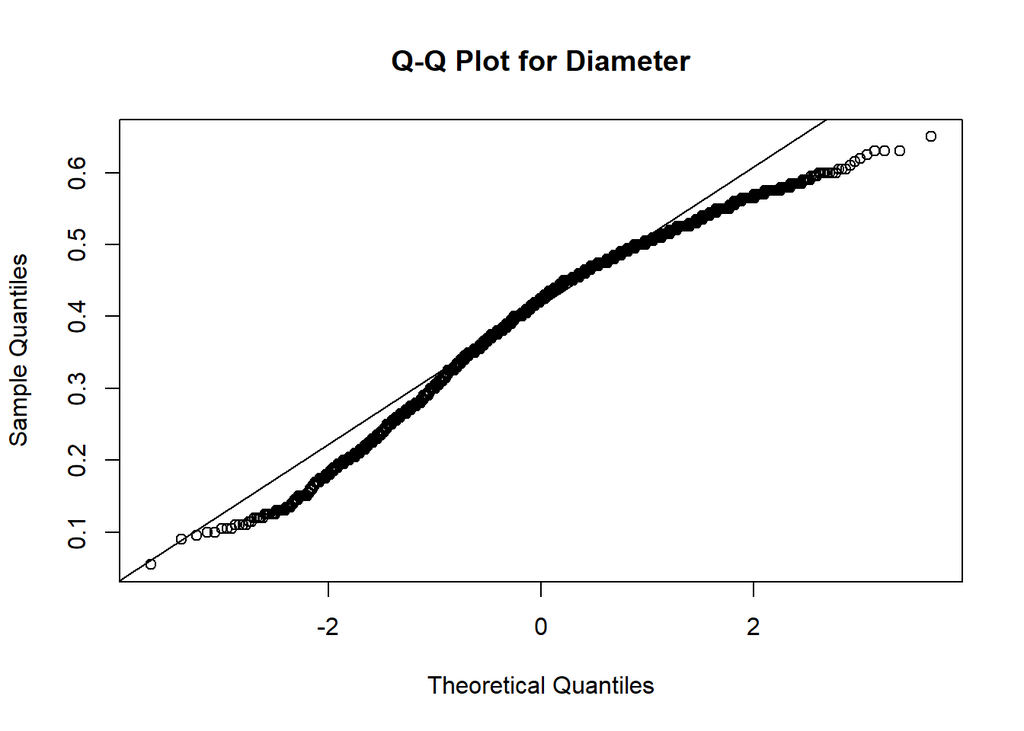

```r
qqnorm(dt$Diameter,main="Q-Q Plot for Diameter",xlab = "Theoretical Quantiles", ylab = "Sample Quantiles")
qqline(dt$Diameter)
```

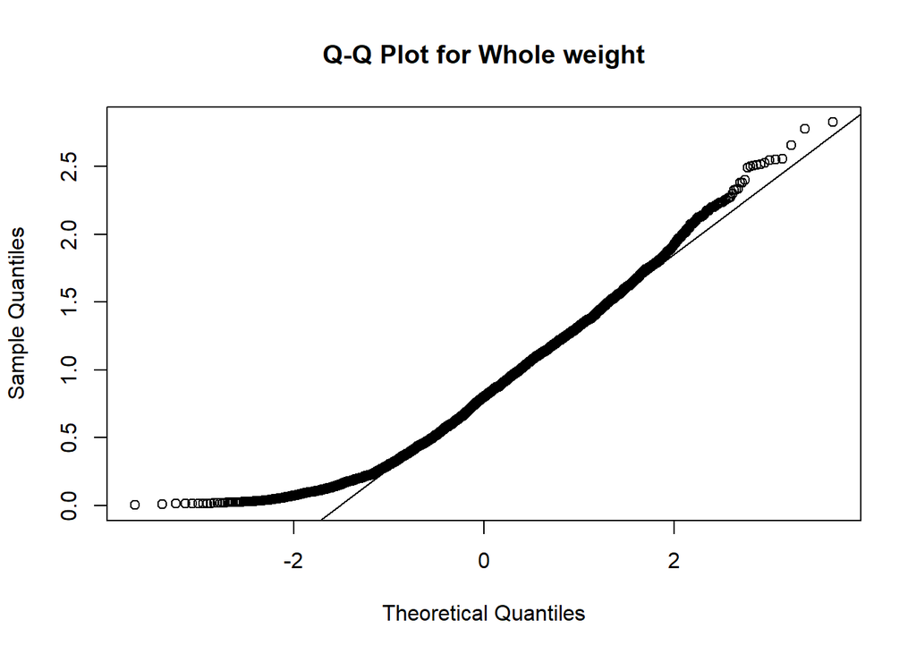

```r
qqnorm(dt$Whole_weight,main="Q-Q Plot for Whole weight",xlab = "Theoretical Quantiles", ylab = "Sample Quantiles")
qqline(dt$Whole_weight)
```

Видим, что распределение достаточно сильно отличается от нормального поэтому для рассчета коэффициента корреляции воспользуемся методом **Спирмена**

```r
sp <- cor.test(dt$Diameter, dt$Whole_weight, method ="spearman")
```

Видим, что коэффициент корреляции достаточно высок 0.9706186 и p.value 0, исходя из чего заключаем, что связь между переменными есть, она положительная и довольно сильная.

# Собственные гипотезы

Логично предположить, что корреляция в размерах не ограничивается корреляцией между Whole_weight и Diameter.

Проверим наличие и других зависимостей. Для начала между различными показателями веса. Как минимум переменная Whole_weight распределена не нормально, так что воспользуемся методом Спирмена.

```r
sw <- cor.test(dt$Shucked_weight, dt$Whole_weight, method ="spearman")
vw <- cor.test(dt$Viscera_weight, dt$Whole_weight, method ="spearman")
shw <- cor.test(dt$Shell_weight, dt$Whole_weight, method ="spearman")
```

Получаем коэффициенты корреляции 0.9761195 , 0.9751164 0.9687692. То-есть корреляция между различными показателями веса действительно есть.

То же самое можно показать и для пары Height - Diameter

```r
hd <- cor.test(dt$Height, dt$Diameter, method ="spearman")
```

0.8957847

Проверим связь между количеством колец и, например, Length

```r
dt$Rings<-as.numeric(dt$Rings)
rl <- cor.test(dt$Rings, dt$Length, method ="spearman")
```

Получаем 0.6039697 что очевидно меньше, чем обнаруженные для других параметров коэффициенты корреляции. Проверим еще Diameter

```r
rd <- cor.test(dt$Rings, dt$Diameter, method ="spearman")
```

0.6223039, тоже не очень высокое значение.

Визуализируем, как в целом соотносятся значения параметра Length и количество колец

Построим boxplot с группировкой по группам с разными количествами колец для значений вектора длины

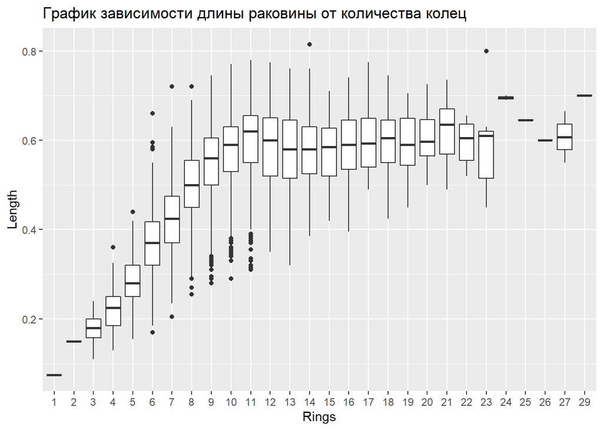

```r
dt$Rings <- as.factor(dt$Rings)
ggplot(dt,aes(y=Length,x=Rings,group=Rings))+geom_boxplot()+ggtitle('График зависимости длины раковины от количества колец')
```

Видно, что до отметки 11 колец при увеличении количества колец длина также увеличивается, однако с увеличением количества колец больше 11 этого не происходит. Попробуем посчитать корреляцию для отфильтрованных данных.

```r
dt$Rings <- as.numeric(dt$Rings)
dt_less_11 <- dt[dt$Rings<11,]
a <- cor.test(dt_less_11$Rings,dt_less_11$Diameter)
b <- cor.test(dt_less_11$Rings,dt_less_11$Length)
```

Получаем для пары Rings-Length значение 0.746417, а для Rings-Diameter 0.7492293 Видим, что в данных для которых значение Rings меньше 11 коэффициент корреляции получился даже немного выше, чем в цельных данных.

А проверим для значений с больше чем 11 кольцами.

```r
dt_more_11 <- dt[dt$Rings>=11,]
c <- cor.test(dt_more_11$Rings,dt_more_11$Diameter)
d <- cor.test(dt_more_11$Rings,dt_more_11$Length)
```

Для Rings-Length 0.0051918, а для Rings-Diameter 0.0315897

Видим, что для моллюсков, у которых больше 11 колец, коэффициенты корреляции сильно меньше.

Проверим и некоторые другие парметры, например Whole_weight и Height

```r
e1 <- cor.test(dt_more_11$Rings,dt_more_11$Whole_weight)
f1 <- cor.test(dt_less_11$Rings,dt_less_11$Whole_weight)
e2 <- cor.test(dt_more_11$Rings,dt_more_11$Height)
f2 <- cor.test(dt_less_11$Rings,dt_less_11$Height)
```

Для Whole_weight видим для группы с количеством колец меньше 11 коэффициент корреляции 0.6637002 , а для группы больше 11 0.0587121, то есть практически 0. Для Height меньше 11 0.633874 , а больше 11 0.1502351.

Тенденция сохраняется

Таким образом, корреляция между количеством колец на раковине и такими параметрами как длина/диаметр/вес может существовать только для особоей с кольцами меньше 11.

Если построим boxplot для визуализации того, как распределено количество колец для групп разного пола, видим, что у группы uvenil у большей части как раз количество колец на раковине меньше 11, соответственно там и коэффициент корреляция между кольцами и длиной/диаметром/весом должен быть выше, чем у male и female. Однако для рассчета коэффициента корреляции между Rings и Length разгруппированного по полам у нас недостаточно данных.

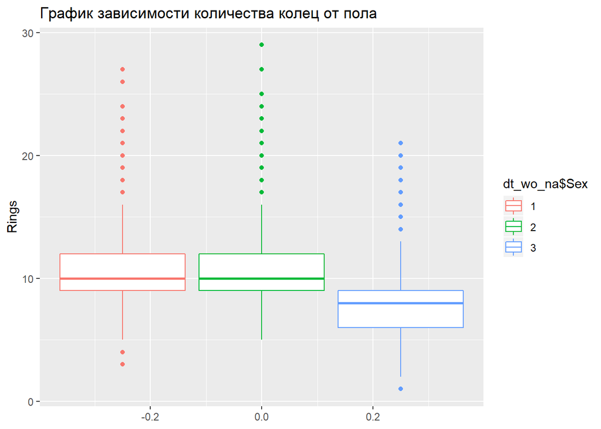

```r
dt_wo_na$Rings <- as.numeric(dt_wo_na$Rings)
ggplot(dt_wo_na,aes(y=Rings,color=dt_wo_na$Sex))+geom_boxplot()+ggtitle('График зависимости количества колец от пола')
```